# Batch Correction

ALSF CCDL - Candace Savonen

*Purpose*: This notebook illustrates how to assess batch effects and how to use ComBat to correct for them.

This method is based on: Johnson, WE, Rabinovic, A, and Li, C (2007). Adjusting batch effects in microarray expression data using Empirical Bayes methods. Biostatistics 8(1):118-127.

## 1) Set up libraries

Install `sva` if you haven’t done so before.

```r
source("https://bioconductor.org/biocLite.R")
biocLite("sva", suppressUpdates = TRUE)
```

```r
# Magrittr pipe
`%>%` <- dplyr::`%>%`
# Load ggplot2 for graphing
library(ggplot2)
```

## 2) Import and set up data

Data downloaded from refine.bio include a metadata tab separated values (“tsv”) file and a data tsv file. These files were obtained from [refine.bio](https://www.refine.bio/) by entering the search term “HEK 293” and then aggregating by `species`.

```r
# Put name of data file
data.filename <- file.path("..", "data", "HOMO_SAPIENS.tsv")
# Unzip the file and direct it to the data folder
unzip(paste0(data.filename, ".zip"), exdir = file.path("..", "data"))
# Read in data tsv file
df <- readr::read_tsv(data.filename) %>%
  tibble::column_to_rownames('X1')
# Make the gene column the rownames so the gene names are out of the way for calculations
```

Prep metadata to be in proper format for batch info to be used by ComBat

```r
# Metadata file name
metadata.filename <- file.path("..", "data", "metadata_HOMO_SAPIENS.tsv")
# Read in data tsv file
metadata <- readr::read_tsv(metadata.filename)
# Put samples in the same order in the dataframe
df <- df[, metadata$refinebio_accession_code]
# Check if the samples are in the same order
all.equal(metadata$refinebio_accession_code, colnames(df))
```

```
[1] TRUE
```

The refine.bio search gave us some cells that aren’t HEK293 so we will need to do some filtering. Because the metadata obtained from combining multiple datasets are not always able to be harmonized, we are going to have to search for HEK 293 cells in a couple different columns.

```r
# Keep only things that have evidence that they are HEK cells
hek293 <- grep("hek|293|hek 293|hek-293",
               paste0(metadata$refinebio_cell_line, metadata$`cell line`, metadata$title),
               ignore.case = TRUE)
# Only keep these in the data and metadata
metadata <- metadata[hek293, ] %>%
  readr::write_tsv("filtered_metadata_HOMO_SAPIENS.tsv")
# Only keep these in the data and metadata
df <- df[, hek293] %>%
  readr::write_tsv("filtered_HOMO_SAPIENS.tsv")
# Take a look at the information we have for these data
metadata
```

| refinebio_accession_code | refinebio_age | refinebio_cell_line | refinebio_compound | refinebio_disease | refinebio_disease_stage | refinebio_genetic_information | refinebio_organism | refinebio_platform | refinebio_race | refinebio_sex | refinebio_source_archive_url | refinebio_source_database | refinebio_specimen_part | refinebio_subject | refinebio_time | refinebio_title | refinebio_treatment | agent | amount to core | antibiotics (yes or no?) | array type | atcc number | background cell line | bioanalyzer results | biomaterial_provider_ch1 | cd44 transfected | cdna processing date | cdna processing technician | cell line | … |
| --- | --- | --- | --- | --- | --- | --- | --- | --- | --- | --- | --- | --- | --- | --- | --- | --- | --- | --- | --- | --- | --- | --- | --- | --- | --- | --- | --- | --- | --- | --- |
| GSM1254227 | NA | hek293 | NA | NA | NA | NA | HOMO_SAPIENS | Affymetrix Human Gene 1.0 ST Array (hugene10st) | NA | NA | NA | GEO | NA | NA | NA | HEK293-CT.R3 | control | NA | NA | NA | NA | NA | NA | NA | NA | NA | NA | NA | HEK293 | … |
| GSM1039981 | NA | hek293t | NA | NA | NA | NA | HOMO_SAPIENS | Affymetrix Human Genome U133 Plus 2.0 Array (hgu133plus2) | NA | NA | NA | GEO | NA | NA | NA | HEK293T cell culture,transfected,biological rep 5 | NA | NA | NA | NA | NA | NA | NA | NA | NA | NA | NA | NA | HEK293T | … |
| GSM546585 | NA | hek-293 | NA | NA | NA | NA | HOMO_SAPIENS | Affymetrix Human Genome U133A 2.0 Array (hgu133a2) | NA | NA | NA | GEO | NA | NA | NA | t469ns_3 | no treatment | NA | NA | NA | NA | NA | NA | NA | NA | NA | NA | NA | HEK-293 | … |
| GSM2129124 | NA | hek293t | NA | NA | NA | NA | HOMO_SAPIENS | Illumina HumanHT-12 V4.0 expression beadchip (Illumina_HumanHT-12_V4.0) | NA | NA | NA | GEO | NA | NA | NA | shCTL_rep1 | NA | NA | NA | NA | NA | NA | NA | NA | NA | NA | NA | NA | HEK293t | … |
| GSM881015 | NA | hek293f | NA | NA | NA | NA | HOMO_SAPIENS | Illumina HumanHT-12 V4.0 expression beadchip (Illumina_HumanHT-12_V4.0) | NA | NA | NA | GEO | NA | NA | time point 1 | Producer culture - fermentation 1- time point 1 | NA | NA | NA | NA | NA | NA | NA | NA | NA | NA | NA | NA | Hek293F | … |
| GSM569353 | NA | embryonic kidney cell line hek | NA | NA | NA | NA | HOMO_SAPIENS | Affymetrix Human Genome U133 Plus 2.0 Array (hgu133plus2) | NA | NA | NA | GEO | NA | NA | NA | Mutatn in the absence of tetracycline, rep3 | NA | untreated | NA | NA | NA | NA | NA | NA | NA | NA | NA | NA | Embryonic kidney cell line HEK | … |
| GSM569345 | NA | embryonic kidney cell line hek | NA | NA | NA | NA | HOMO_SAPIENS | Affymetrix Human Genome U133 Plus 2.0 Array (hgu133plus2) | NA | NA | NA | GEO | NA | NA | NA | WT in the absence of tetracycline, rep1 | NA | untreated | NA | NA | NA | NA | NA | NA | NA | NA | NA | NA | Embryonic kidney cell line HEK | … |
| GSM1442100 | NA | hek293t | NA | NA | NA | NA | HOMO_SAPIENS | Affymetrix Human Genome U133 Plus 2.0 Array (hgu133plus2) | NA | NA | NA | GEO | NA | NA | NA | PEI_HEK293T cell culture,8h,transfected,biological rep 2 | NA | NA | NA | NA | NA | NA | NA | NA | NA | NA | NA | NA | HEK293T | … |
| GSM2089908 | NA | hek293t | NA | NA | NA | NA | HOMO_SAPIENS | Affymetrix Human Genome U219 Array (hgu219) | NA | NA | NA | GEO | NA | NA | NA | HEK293T_siRNA(dharmacon)BRD1_1 | NA | NA | NA | NA | NA | NA | NA | NA | NA | NA | NA | NA | HEK293T | … |
| GSM693950 | NA | embryonic kidney cell line hek 293t | NA | NA | NA | NA | HOMO_SAPIENS | Affymetrix Human Genome U133 Plus 2.0 Array (hgu133plus2) | NA | NA | NA | GEO | NA | NA | 72h | HEK293T_mock-transfection_72h_rep2 | NA | NA | NA | NA | NA | NA | NA | NA | NA | NA | NA | NA | embryonic kidney cell line HEK 293T | … |

[output cut: 612 more lines]

## 3) Perform Principal Components Analysis

```r
# Calculate PCA
pca <- prcomp(t(df))
# Make into dataframe for plotting with ggplot2
pca.df <- data.frame(pca$x[, 1:2],
                     dataset = metadata$series_id)
```

Plot these PC scores. We will likely see a difference between the datasets.

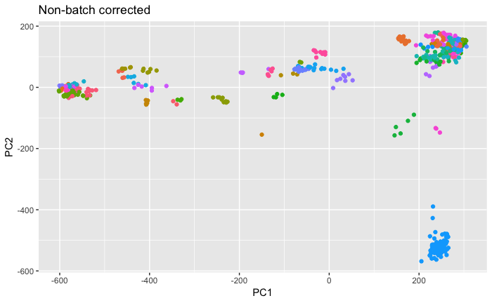

```r
ggplot(pca.df, aes(x = PC1, y = PC2, color = dataset)) +
  geom_point() +
  theme(legend.position = "none") +
  ggtitle("Non-batch corrected")
```

## 4) Peform ComBat correction

To run ComBat, we need batch information, in this case we will use the dataset ids.

```r
corrected.df <- sva::ComBat(as.matrix(df), metadata$series_id)
```

```
Found66batches
Note: one batch has only one sample, setting mean.only=TRUE
Adjusting for0covariate(s) or covariate level(s)
```

```
Standardizing Data across genes
```

```
Fitting L/S model and finding priors
Finding parametric adjustments
Adjusting the Data
```

## 5) Re-evaluate PCA after batch correction

Let’s see if ComBat helped with making PC scores less divided by batches.

```r
# Calculate PCA
corrected.pca <- prcomp(t(corrected.df))
# Make into dataframe for plotting with ggplot2
corrected.pca.df <- data.frame(corrected.pca$x[, 1:2],
                               dataset = metadata$series_id)
```

Plot these batch corrected data PC scores.

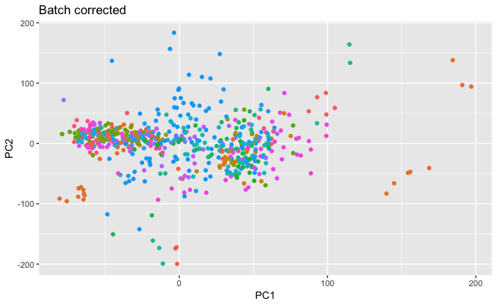

```r
ggplot(corrected.pca.df, aes(x = PC1, y = PC2, color = dataset)) +
  geom_point() +
  theme(legend.position = "none") +
  ggtitle("Batch corrected")
```

## 6) Save batch corrected data to tsv file

```r
corrected.df %>% as.data.frame() %>%
  tibble::rownames_to_column("gene") %>%
  readr::write_tsv("HEK293_batch_corrected_exprs.tsv")
```